# Practical_Machine_Learning

Xiaoyu Liu

September 21, 2014

Introduction In nowadays, large amount of data about personal activity is collected relatively inexpensively. This report predicted how well the exercise participants’ performance based on the data from accelerometers placed on the belt, forearm, arm, and dumbell of six participants.

Environment Setup ##Libraries The following libraries were used throughout the code.

```r
library(caret)
library(kernlab)
library(randomForest)
```

```r
library(corrplot)
```

## Testing and training Data

Two data files were provided by the course. Loading training dataset

```r
# read the csv file for training
data_training <- read.csv("./data/pml-training.csv", na.strings= c("NA",""," "))
```

Loading testing dataset

```r
# apply the same treatment to the final testing data
data_test <- read.csv("./data/pml-testing.csv", na.strings= c("NA",""," "))
```

# Data Cleaning

NA values in the datasets would bring negative impact on the data analysis. So they were removed from the datasets.

Clean training dataset

```r
# clean the data by removing columns with NAs etc
data_training_NAs <- apply(data_training, 2, function(x) {sum(is.na(x))})
data_training_clean <- data_training[,which(data_training_NAs == 0)]

# remove identifier columns such as name, timestamps etc
data_training_clean <- data_training_clean[8:length(data_training_clean)]
```

Clean testing dataset

```r
data_test_NAs <- apply(data_test, 2, function(x) {sum(is.na(x))})
data_test_clean <- data_test[,which(data_test_NAs == 0)]
data_test_clean <- data_test_clean[8:length(data_test_clean)]
```

```r
# split the cleaned testing data into training and cross validation
inTrain <- createDataPartition(y = data_training_clean$classe, p = 0.7, list = FALSE)
training <- data_training_clean[inTrain, ]
crossval <- data_training_clean[-inTrain, ]
```

We use the Random Forests method to predict the classification, which applies bagging to tree learners.

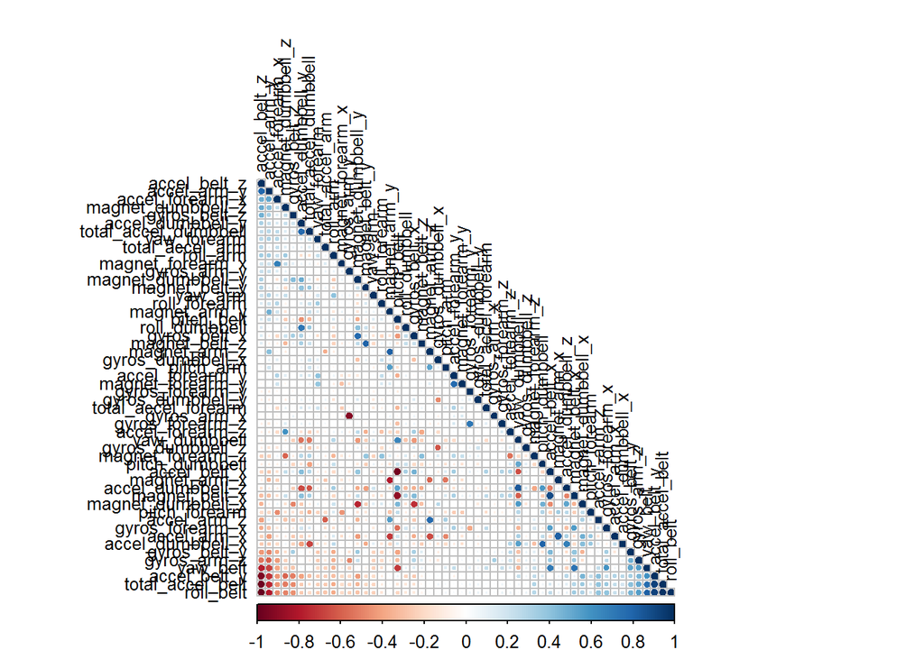

```r
#Plot
correlMatrix <- cor(training[, -length(training)])
corrplot(correlMatrix, order = "FPC", method = "circle", type = "lower", tl.cex = 0.8,  tl.col = rgb(0, 0, 0))
```

A regression model was built with the outcome set to the training class and all the other variables used to predict.

```r
model <- randomForest(classe ~ ., data = training)
```

# Cross-Validataion

The model was then used to classify the remaining 30% of data. The results were placed in a confusion matrix along with the actual classifications in order to determine the accuracy of the model.

```r
predictCrossVal <- predict(model, crossval)
confusionMatrix(crossval$classe, predictCrossVal)
```

```
## Confusion Matrix and Statistics
##
##           Reference
## Prediction    A    B    C    D    E
##          A 1672    2    0    0    0
##          B    8 1127    4    0    0
##          C    0    2 1024    0    0
##          D    0    0   14  949    1
##          E    0    0    0    4 1078
##
## Overall Statistics
##
##                Accuracy : 0.994
##                  95% CI : (0.992, 0.996)
##     No Information Rate : 0.285
##     P-Value [Acc > NIR] : <2e-16
##
##                   Kappa : 0.992
##  Mcnemar's Test P-Value : NA
##
## Statistics by Class:
##
##                      Class: A Class: B Class: C Class: D Class: E
## Sensitivity             0.995    0.996    0.983    0.996    0.999
## Specificity             1.000    0.997    1.000    0.997    0.999
## Pos Pred Value          0.999    0.989    0.998    0.984    0.996
## Neg Pred Value          0.998    0.999    0.996    0.999    1.000
## Prevalence              0.285    0.192    0.177    0.162    0.183
## Detection Rate          0.284    0.192    0.174    0.161    0.183
## Detection Prevalence    0.284    0.194    0.174    0.164    0.184
## Balanced Accuracy       0.997    0.997    0.991    0.996    0.999
```

Predictions

```r
predictTest <- predict(model, data_test_clean)
predictTest
```

```
##  1  2  3  4  5  6  7  8  9 10 11 12 13 14 15 16 17 18 19 20
##  B  A  B  A  A  E  D  B  A  A  B  C  B  A  E  E  A  B  B  B
## Levels: A B C D E
```

# Conclusions

It can accurately predict the exercis performance of a specific person using a relatively simple model with enough data.